# Single Cancer Analysis and Figures

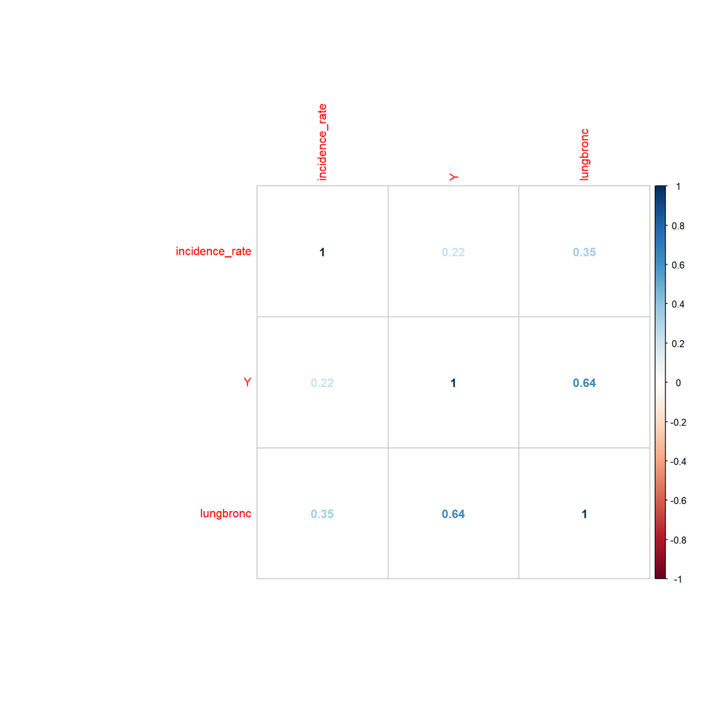

```r
corrplot(cor(cbind(X,Y)[,c("Y","incidence_rate","lungbronc")],method="kendall"),method = "number",order = "hclust")
```

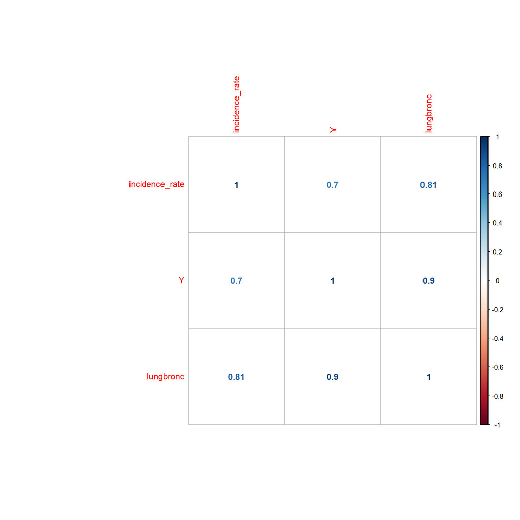

```r
corrplot(cor(cbind(X,Y)[,c("Y","incidence_rate","lungbronc")],method="pearson"),method = "number",order = "hclust")
```

It’s actually quite remarkable… union county was mentioned in the JAMA article as well. The outlier also agrees with the data model, the poverty level is above the national average, the median income is low, the incidence rate is 3 times higher than that of the next highest county. Almost zero of the population possess a college education and the percent of public coverage is lower than the national average of 19.2400722%.

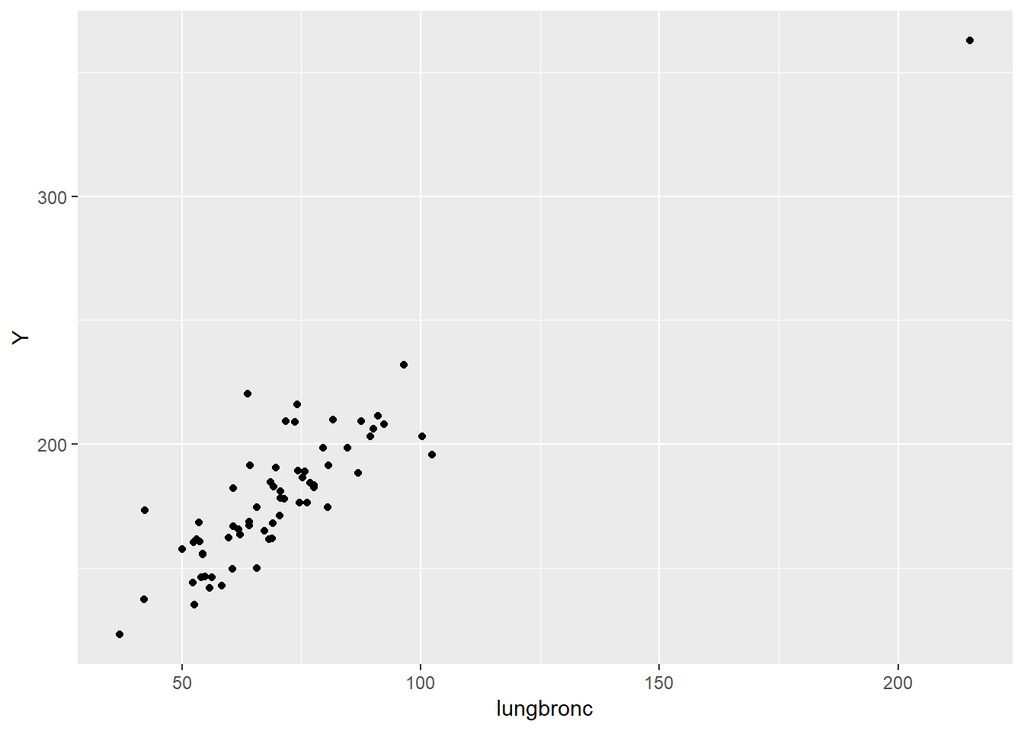

```r
ggplot(data=as.data.frame(cbind(X,Y)),aes(y=Y,x=lungbronc)) + geom_point()
```